# Characterising information loss due to aggregating epidemic model outputs

## Results

#### Comparison of all ensembles

Figure 1

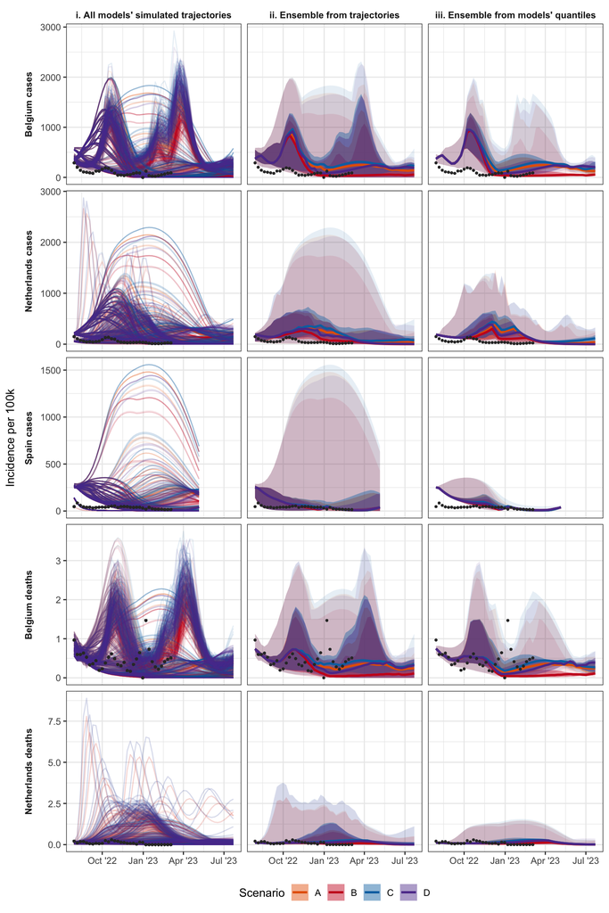

#### Difference between uncertainty ranges

Figure 2

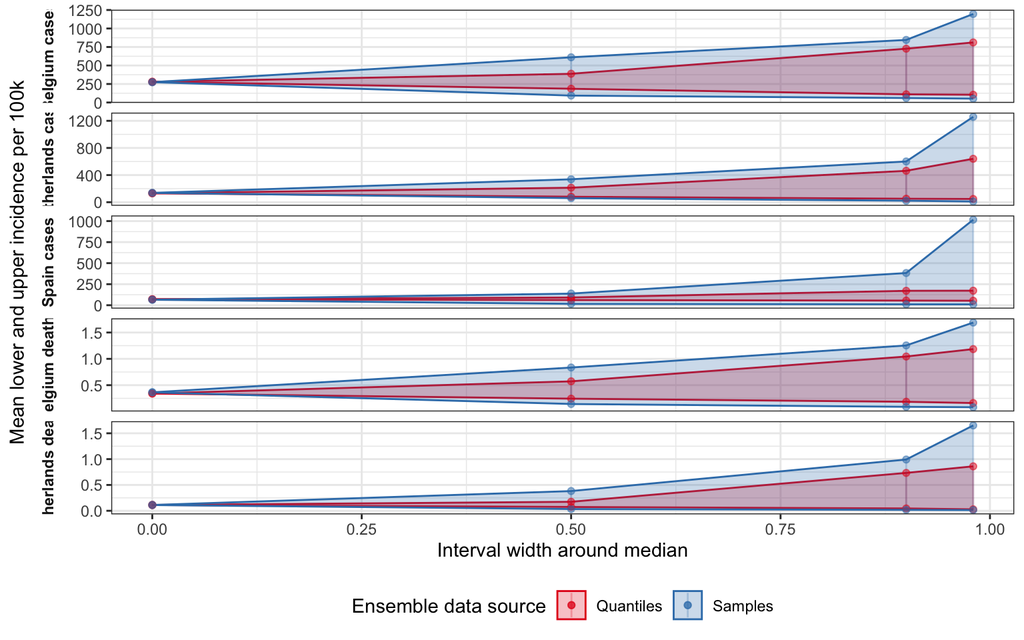

Figure 2 shows the mean lower and upper incidence per 100,000 population, at increasing distances from the median (interval width). The median estimate is at 0 on the x-axis, and an interval width at 0.98 represents the 1%-99% credibility interval around the median. With increasing levels of uncertainty, the distances between the lower and upper bounds are reduced in an ensemble created from quantile summaries of model simulations, compared to sampled simulated trajectories.

#### Conditioning samples on an increasing amount of data

Text:

Figure 3. Weighted ensemble forecasts of incidence 4, 8, and 16 weeks ahead of available data, with available data increasing weekly over time. Showing median (lines) & 50% quantiles (shaded ribbons). Each sample trajectory started from 30 July 2022 and was weighted using its inverse mean absolute error against all available data. Consecutive weekly forecasts were created from updating weights with each week’s observed data. We started with 4 weeks observed data and then created consecutive forecasts at each week, so that weights update with increasing weekly observed data becoming available. This meant the earliest forecast is an ensemble of sample trajectories from the 27 August 2022 (vertical dashed line), using 4 weeks’ observed data to weight sample trajectories, and gives a 4 week ahead forecast for the 24 September (start of purple ribbon), an 8 week ahead forecast for the 22 October (start of pink ribbon), and 16 week forecast from 17 December 2022 (start of yellow ribbon).

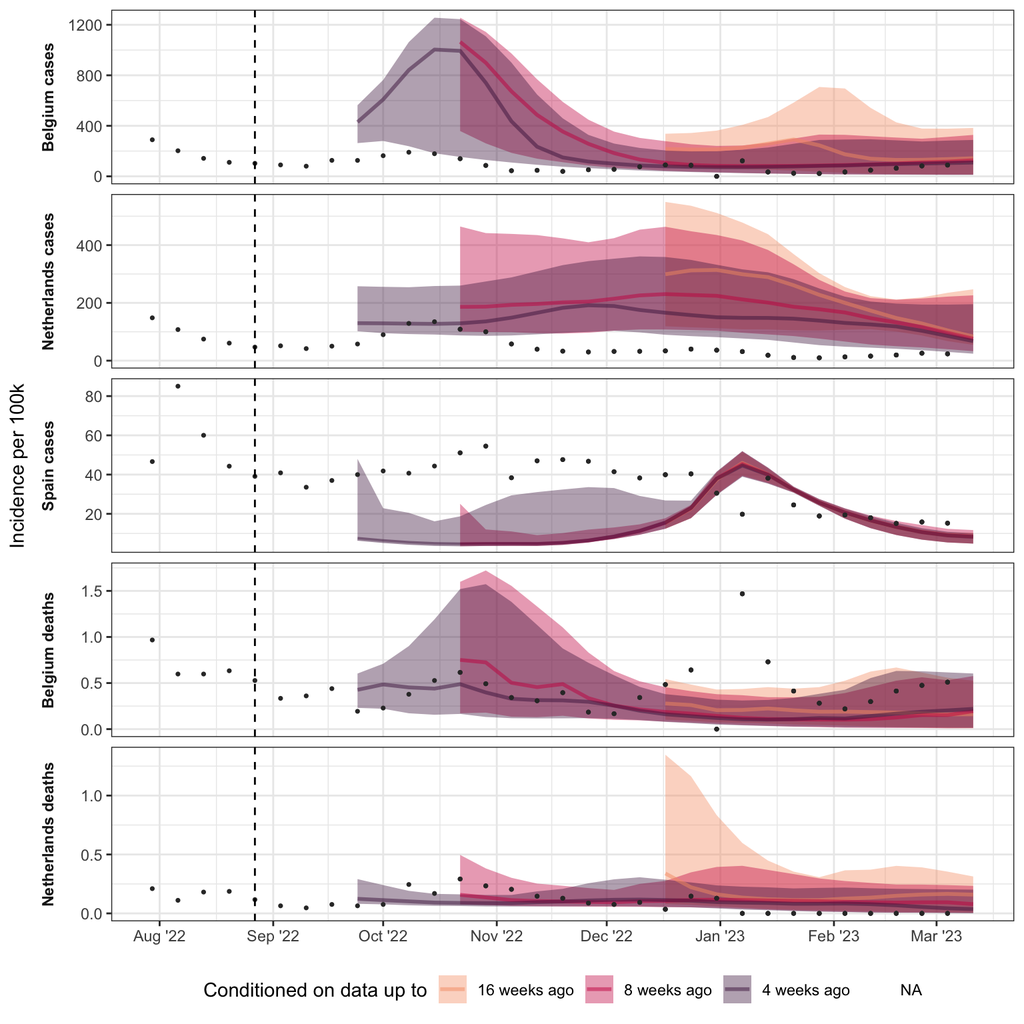

We show varying lengths of forecasts repeatedly conditioned on simulated trajectories’ performance against each week’s data. We start with performance from 4-weeks-observed data and use this to weight an ensemble that forecasts 4, 8, or 16 weeks ahead into the future.